# Lab3: Association Rules

Aniketh V, Indy Dhillon, Suchismita Moharana, Jason Rupp

11/24/2020

## Business Understanding 1

The dataset selected for this project was collected by the US Census Bureau and the Bureau of Labor Statistics over the course of 1994 and 1995 for the Current Population Survey (CPS). The main purpose of the CPS is to obtain current information on the status of the labor force in the United States. More specifically, this survey is conducted to enumerate the number of jobless and unemployed individuals as well as to get an idea about the social well-being of the citizens.

The Current Population Survey was developed in the late 1930s after the Great Depression, as prior there was not an effective technique to classify the labor force. A great need arose for a reliable survey of the population after this period of widespread unemployment. Previously, there were several indirect surveying techniques employed, however there were great discrepancies between these methods. The first surveys began in the 1940s and responsibility for conducting the survey has changed hands in the government, but currently, the survey portion is conducted by the US Census Bureau and the data is analyzed by the Bureau of Labor Statistics.

The CPS is conducted monthly and is administered by asking a series of questions pertaining to socioeconomic factors of roughly 60,000 probability sampled households from all 50 states and the District of Columbia. Eligible candidates must be over the age of 15, not in the Armed Forces, or in an institution such as a prison, nursing home or long-term health care facility. Typically, labor force questions are asked pertaining to eligible workers in the household, in addition to supplemental questions asked that are of particular interest to labor force analysts. These subjects range greatly in the both the frequency in which they are asked, as in, annually, biannually, or one-time, as well the topics. Supplemental survey topics which vary monthly and cover questions relating to many differing topics, such as veterans status, child support, displaced workers, fertility, disability, school enrollment, just to name a few.

This data was obtained from the University of California Irvine Machine Learning repository, which a citation and a direct link to the dataset can be found [here](https://www2.1010data.com/documentationcenter/prod/Tutorials/MachineLearningExamples/CensusIncomeDataSet.html).

Due to the wide-ranging nature of this survey, outcomes derived from this data would be highly dependent on the questions at hand. For purposes of this study, the main goals will be classification of two variables. The first variable will be the income as a binomial response, above or below $50,000 annually. The second classification variable will be created from the level of education feature, whether the person is a college graduate or not.

For these studies, association rules will be created. Association rule mining is likelihood of co-occurence and there is no causality. The effectiveness of a good prediction apriori algorithm will be assessed by confidence of the outcome. This validation method of apriori algorithm will help graduate schools to target students who might be interested for higher studies. Since, we do not need any causality here, so association rule will work just fine.

With current pandemic, grad schools are facing dropping number of enrollment which is due to various reasons (i.e. contamination issue at campus, layoff and furloughs in many different comanies forcing working students to take break). Grad schools can target students who are more likely to pursue in higher studies by giving them scholarships and lure them to enroll.

## Data Understanding 1

A subset of features were selected from the larger census unemployment dataset with exception to 2 column. One of the features that was created was done with the `age` variable of the census data. The records were split into age groups, so that age could be categorically represented in the rules that were created. Another feature which was generated from the data set is a representation of education level. The feature was binomial and called `graduated`; if the person has attained a 4 year degree or higher, they’re considered to have graduated and would have a value of true. Omission of some features from the larger dataset was done to simplify the rules, as well as remove any feature which may add unnecessary difficulty to interpretation. Below is a table of the features that were used to map association rules with regard to education and income.

| Feature | Datatype | Summary |
| --- | --- | --- |
| age_group | Categorical | Age group of record |
| det_ind_code | Categorical | Value assigned to industry of employment |
| det_occ_code | Categorical | Code associated with occupation |
| major_occ_code | Categorical | Description of the role of the individual |
| sex | Categorical | Gender of individual |
| education | Categorical | Highest Level of education attained |
| martial_stat | Categorical | Martial statues of individual; married, single, or divorced |
| race | Categorical | Race of the individual e.g. White, Asian, Hispanic, etc… |
| tax_filer_stat | Categorical | current status for their tax filing |
| citizenship | Categorical | United States citizen or other |
| graduated | Categorical | Achieved higher education degree |
| income_50k | Categorical | Annual income greater than $50,000 annually |

```
## [1] 3229   43
```

The above output shows that there are a number of duplicate records. It doesn’t seem that they are true duplicates, just separate records with the same features categorically. Either way, the duplicates are removed to not bias any of the statistics surrounding the association rules. If there was a high duplicate rate for some of the records, it could skew to support parameters for the rules. To avoid this issue, they will simply be removed.

```
## Classes 'tbl_df', 'tbl' and 'data.frame':    196294 obs. of  12 variables:
##  $ age_group     : Factor w/ 3 levels "<18","18-64",..: 3 2 1 1 1 2 2 2 2 2 ...
##  $ det_ind_code  : Factor w/ 52 levels "0","1","2","3",..: 1 5 1 1 1 41 35 5 44 5 ...
##  $ det_occ_code  : Factor w/ 47 levels "0","1","2","3",..: 1 35 1 1 1 11 4 41 27 38 ...
##  $ major_occ_code: Factor w/ 15 levels "Adm support including clerical",..: 7 9 7 7 7 11 3 5 1 6 ...
##  $ sex           : Factor w/ 2 levels "Female","Male": 1 2 1 1 1 1 2 1 1 2 ...
##  $ education     : Factor w/ 17 levels "10th grade","11th grade",..: 13 17 1 11 11 17 10 13 17 17 ...
##  $ marital_stat  : Factor w/ 7 levels "Divorced","Married-A F spouse present",..: 7 1 5 5 5 3 3 5 3 3 ...
##  $ race          : Factor w/ 5 levels "Amer Indian Aleut or Eskimo",..: 5 5 2 5 5 1 5 5 5 5 ...
##  $ tax_filer_stat: Factor w/ 6 levels "Head of household",..: 5 1 5 5 5 3 3 6 3 3 ...
##  $ citizenship   : Factor w/ 5 levels "Foreign born- Not a citizen of U S",..: 5 5 1 5 5 5 5 5 5 5 ...
##  $ graduated     : Factor w/ 2 levels "no","yes": 1 1 1 1 1 1 2 1 1 1 ...
##  $ income_50k    : Factor w/ 2 levels "- 50000.","50000+.": 1 1 1 1 1 1 1 1 1 1 ...
```

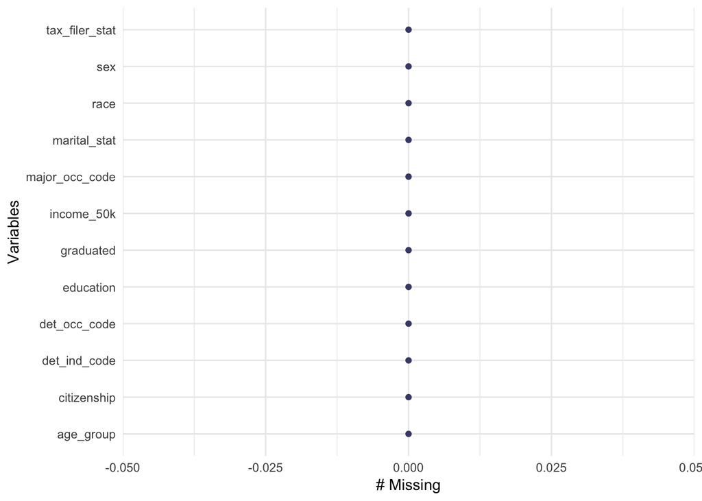

The above plot shows that there are not any missing values for this subset of data. This will be very helpful when it comes to developing a rule model.

## Data Understanding 2

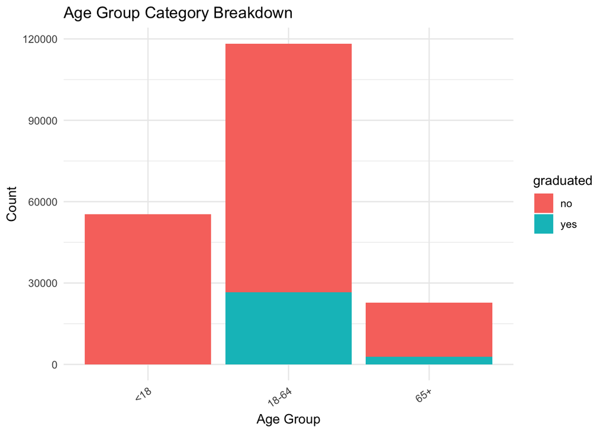

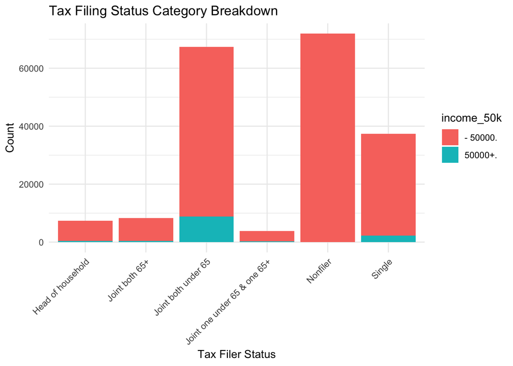

[figure not shown]

The second graph is also a simple bar graph that compares tax filer attribute in response to income. This is useful to check the different categories within this attribute and how it compares to income.

All the above graphs can be used to find potential items that will be for our rules. We would only expect the categories that would have high graduation/income above 50K to show up in our association rules output.

## Modeling and Evaluation 1

```
## Apriori
##
## Parameter specification:
##  confidence minval smax arem  aval originalSupport maxtime support minlen
##        0.74    0.1    1 none FALSE            TRUE       5    0.04      1
##  maxlen target   ext
##      10  rules FALSE
##
## Algorithmic control:
##  filter tree heap memopt load sort verbose
##     0.1 TRUE TRUE  FALSE TRUE    2    TRUE
##
## Absolute minimum support count: 7851
##
## set item appearances ...[1 item(s)] done [0.00s].
## set transactions ...[146 item(s), 196294 transaction(s)] done [0.19s].
## sorting and recoding items ... [34 item(s)] done [0.03s].
## creating transaction tree ... done [0.18s].
## checking subsets of size 1 2 3 4 5 6 7 8 9 10 done [0.04s].
## writing ... [5 rule(s)] done [0.00s].
## creating S4 object  ... done [0.08s].
```

```
##     lhs                                                rhs               support confidence     lift count
## [1] {age_group=18-64,
##      major_occ_code=Professional specialty,
##      race=White,
##      citizenship=Native- Born in the United States} => {graduated=yes} 0.0422071  0.7480137 4.984913  8285
```

```
## [1] 1
```

```
## Apriori
##
## Parameter specification:
##  confidence minval smax arem  aval originalSupport maxtime support minlen
##         0.2    0.1    1 none FALSE            TRUE       5    0.02      1
##  maxlen target   ext
##      10  rules FALSE
##
## Algorithmic control:
##  filter tree heap memopt load sort verbose
##     0.1 TRUE TRUE  FALSE TRUE    2    TRUE
##
## Absolute minimum support count: 3925
##
## set item appearances ...[1 item(s)] done [0.00s].
## set transactions ...[161 item(s), 196294 transaction(s)] done [0.19s].
## sorting and recoding items ... [59 item(s)] done [0.02s].
## creating transaction tree ... done [0.17s].
## checking subsets of size 1 2 3 4 5 6 7 8 9 10 done [0.15s].
## writing ... [21 rule(s)] done [0.00s].
## creating S4 object  ... done [0.08s].
```

```
##     lhs                                                rhs                     support confidence     lift count
## [1] {age_group=18-64,
##      sex=Male,
##      marital_stat=Married-civilian spouse present,
##      race=White,
##      tax_filer_stat=Joint both under 65,
##      citizenship=Native- Born in the United States} => {income_50k=50000+.} 0.03268057  0.2412017 3.823812  6415
```

```
## [1] 1
```

When it comes to association rules the evaluation is very subjective. Based on trial and error we picked different parameter values to obtain the optimal amount of rules. The below values for support and confidence only yielded 1 rules for each algorithm:

- (support = 0.04, confidence = 0.74)
- (support = 0.02, confidence = 0.20)

We found the above values too aggressive for our search criteria and deduced that support values less than the above numbers gave us the best results.

```
## Apriori
##
## Parameter specification:
##  confidence minval smax arem  aval originalSupport maxtime support minlen
##        0.74    0.1    1 none FALSE            TRUE       5    0.03      1
##  maxlen target   ext
##      10  rules FALSE
##
## Algorithmic control:
##  filter tree heap memopt load sort verbose
##     0.1 TRUE TRUE  FALSE TRUE    2    TRUE
##
## Absolute minimum support count: 5888
##
## set item appearances ...[1 item(s)] done [0.00s].
## set transactions ...[146 item(s), 196294 transaction(s)] done [0.18s].
## sorting and recoding items ... [37 item(s)] done [0.02s].
## creating transaction tree ... done [0.17s].
## checking subsets of size 1 2 3 4 5 6 7 8 9 10 done [0.05s].
## writing ... [24 rule(s)] done [0.00s].
## creating S4 object  ... done [0.07s].
```

```
##      lhs                                                rhs                support confidence     lift count
## [1]  {major_occ_code=Professional specialty,
##       tax_filer_stat=Joint both under 65}            => {graduated=yes} 0.03505966  0.7621262 5.078961  6882
## [2]  {major_occ_code=Professional specialty,
##       marital_stat=Married-civilian spouse present}  => {graduated=yes} 0.03644533  0.7617121 5.076201  7154
## [3]  {age_group=18-64,
##       major_occ_code=Professional specialty}         => {graduated=yes} 0.05123947  0.7451474 4.965811 10058
## [4]  {major_occ_code=Professional specialty,
##       race=White}                                    => {graduated=yes} 0.04644564  0.7420037 4.944861  9117
## [5]  {major_occ_code=Professional specialty,
##       marital_stat=Married-civilian spouse present,
##       tax_filer_stat=Joint both under 65}            => {graduated=yes} 0.03485588  0.7629349 5.084350  6842
## [6]  {age_group=18-64,
##       major_occ_code=Professional specialty,
##       tax_filer_stat=Joint both under 65}            => {graduated=yes} 0.03505966  0.7622951 5.080087  6882
## [7]  {major_occ_code=Professional specialty,
##       race=White,
##       tax_filer_stat=Joint both under 65}            => {graduated=yes} 0.03131018  0.7607377 5.069708  6146
## [8]  {major_occ_code=Professional specialty,
##       tax_filer_stat=Joint both under 65,
##       citizenship=Native- Born in the United States} => {graduated=yes} 0.03101470  0.7542121 5.026220  6088
## [9]  {age_group=18-64,
##       major_occ_code=Professional specialty,
##       marital_stat=Married-civilian spouse present}  => {graduated=yes} 0.03559966  0.7618009 5.076794  6988
## [10] {major_occ_code=Professional specialty,
##       marital_stat=Married-civilian spouse present,
##       race=White}                                    => {graduated=yes} 0.03262453  0.7609316 5.071000  6404
```

```
##      support confidence     lift count
## 1 0.03505966  0.7621262 5.078961  6882
## 2 0.03644533  0.7617121 5.076201  7154
## 3 0.05123947  0.7451474 4.965811 10058
## 4 0.04644564  0.7420037 4.944861  9117
## 5 0.03485588  0.7629349 5.084350  6842
## 6 0.03505966  0.7622951 5.080087  6882
```

```
## [1] 24
```

```
##     lhs                                                rhs                support confidence     lift count
## [1] {age_group=18-64,
##      major_occ_code=Professional specialty,
##      marital_stat=Married-civilian spouse present,
##      race=White,
##      tax_filer_stat=Joint both under 65}            => {graduated=yes} 0.03115735  0.7618336 5.077011  6116
## [2] {major_occ_code=Professional specialty,
##      marital_stat=Married-civilian spouse present,
##      race=White,
##      citizenship=Native- Born in the United States} => {graduated=yes} 0.03043904  0.7606620 5.069203  5975
## [3] {age_group=18-64,
##      major_occ_code=Professional specialty,
##      marital_stat=Married-civilian spouse present,
##      tax_filer_stat=Joint both under 65,
##      citizenship=Native- Born in the United States} => {graduated=yes} 0.03084149  0.7552395 5.033067  6054
## [4] {age_group=18-64,
##      major_occ_code=Professional specialty,
##      race=White,
##      citizenship=Native- Born in the United States} => {graduated=yes} 0.04220710  0.7480137 4.984913  8285
```

```
## [1] 4
```

```
## Apriori
##
## Parameter specification:
##  confidence minval smax arem  aval originalSupport maxtime support minlen
##        0.25    0.1    1 none FALSE            TRUE       5   0.015      1
##  maxlen target   ext
##      10  rules FALSE
##
## Algorithmic control:
##  filter tree heap memopt load sort verbose
##     0.1 TRUE TRUE  FALSE TRUE    2    TRUE
##
## Absolute minimum support count: 2944
##
## set item appearances ...[1 item(s)] done [0.00s].
## set transactions ...[161 item(s), 196294 transaction(s)] done [0.19s].
## sorting and recoding items ... [75 item(s)] done [0.02s].
## creating transaction tree ... done [0.17s].
## checking subsets of size 1 2 3 4 5 6 7 8 9 10 done [0.21s].
## writing ... [11 rule(s)] done [0.00s].
## creating S4 object  ... done [0.08s].
```

```
##      lhs                                                rhs                     support confidence     lift count
## [1]  {major_occ_code=Executive admin and managerial} => {income_50k=50000+.} 0.01830418  0.2875550 4.558660  3593
## [2]  {age_group=18-64,
##       major_occ_code=Executive admin and managerial} => {income_50k=50000+.} 0.01768775  0.2871320 4.551953  3472
## [3]  {major_occ_code=Executive admin and managerial,
##       race=White}                                    => {income_50k=50000+.} 0.01697454  0.2955735 4.685778  3332
## [4]  {major_occ_code=Executive admin and managerial,
##       citizenship=Native- Born in the United States} => {income_50k=50000+.} 0.01674020  0.2902058 4.600683  3286
## [5]  {major_occ_code=Professional specialty,
##       race=White}                                    => {income_50k=50000+.} 0.01569075  0.2506714 3.973938  3080
## [6]  {sex=Male,
##       education=Bachelors degree(BA AB BS)}          => {income_50k=50000+.} 0.01549207  0.3058433 4.848587  3041
## [7]  {age_group=18-64,
##       major_occ_code=Executive admin and managerial,
##       race=White}                                    => {income_50k=50000+.} 0.01639887  0.2955651 4.685646  3219
## [8]  {age_group=18-64,
##       major_occ_code=Executive admin and managerial,
##       citizenship=Native- Born in the United States} => {income_50k=50000+.} 0.01616962  0.2897836 4.593990  3174
## [9]  {major_occ_code=Executive admin and managerial,
##       race=White,
##       citizenship=Native- Born in the United States} => {income_50k=50000+.} 0.01587924  0.2970269 4.708819  3117
## [10] {age_group=18-64,
##       major_occ_code=Professional specialty,
##       race=White}                                    => {income_50k=50000+.} 0.01513546  0.2500421 3.963961  2971
```

```
##      support confidence     lift count
## 1 0.01830418  0.2875550 4.558660  3593
## 2 0.01768775  0.2871320 4.551953  3472
## 3 0.01697454  0.2955735 4.685778  3332
## 4 0.01674020  0.2902058 4.600683  3286
## 5 0.01569075  0.2506714 3.973938  3080
## 6 0.01549207  0.3058433 4.848587  3041
```

```
## [1] 11
```

```
##     lhs                                                rhs                     support confidence     lift count
## [1] {sex=Male,
##      education=Bachelors degree(BA AB BS)}          => {income_50k=50000+.} 0.01549207  0.3058433 4.848587  3041
## [2] {age_group=18-64,
##      major_occ_code=Executive admin and managerial,
##      race=White,
##      citizenship=Native- Born in the United States} => {income_50k=50000+.} 0.01533924  0.2970307 4.708879  3011
## [3] {age_group=18-64,
##      major_occ_code=Professional specialty,
##      race=White}                                    => {income_50k=50000+.} 0.01513546  0.2500421 3.963961  2971
```

```
## [1] 3
```

The below output contains values that we found were the most ideal. It generated 4 rules for the itemsets for graduation and 3 rules for the itemsets that contain income.

## Modeling and Evaluation 2

Overview for Income Rules: The above analysis provides the frequent itemsets that are associated that we mined. From the overall picture shows us the itemsets that were picked based on the parameters we passed. To check the frequent itemsets that are commonly associated with income 50000+ we used support values of 1.5% and a confidence of 25%. This gave us a 3 rules. The lift values for these rules are a little lower than grad rules.

As shown in the above analysis both blocks showed very different results. The first code block held aggressive values for support and confidence which gave us only 1 rule. Compared to the the parameters we felts were the most optimum gave us best rules for our analysis.

## Modeling and Evaluation 3

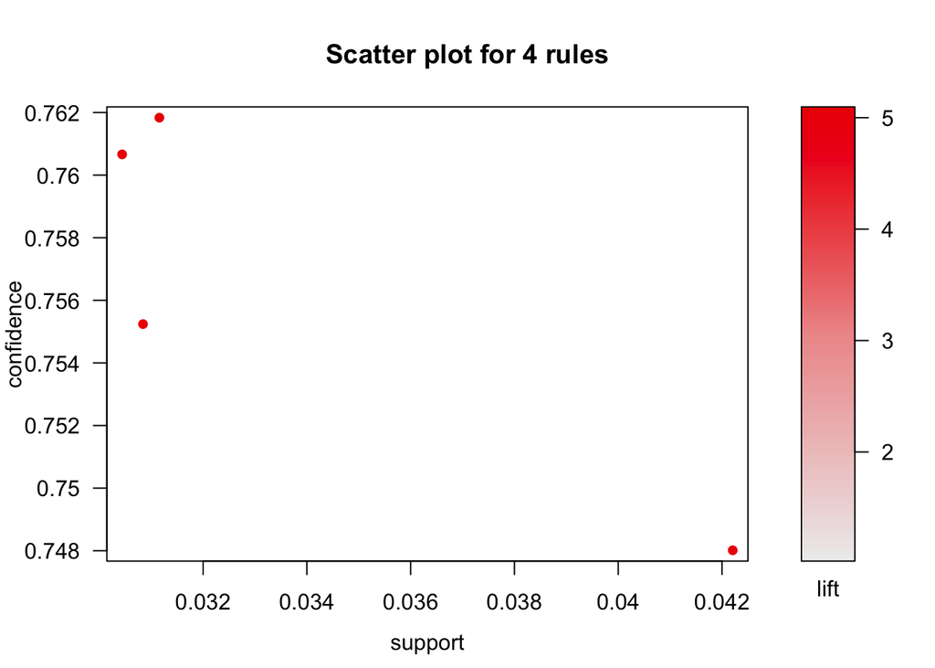

In the above scatter plot the support and confidence of the rules for income over $50k and graduated and displayed. For graduated we were able to find 3 rules with about 3% support and one rule with over 4% support, the confidences and lift were all comparable with confidence around 75%.

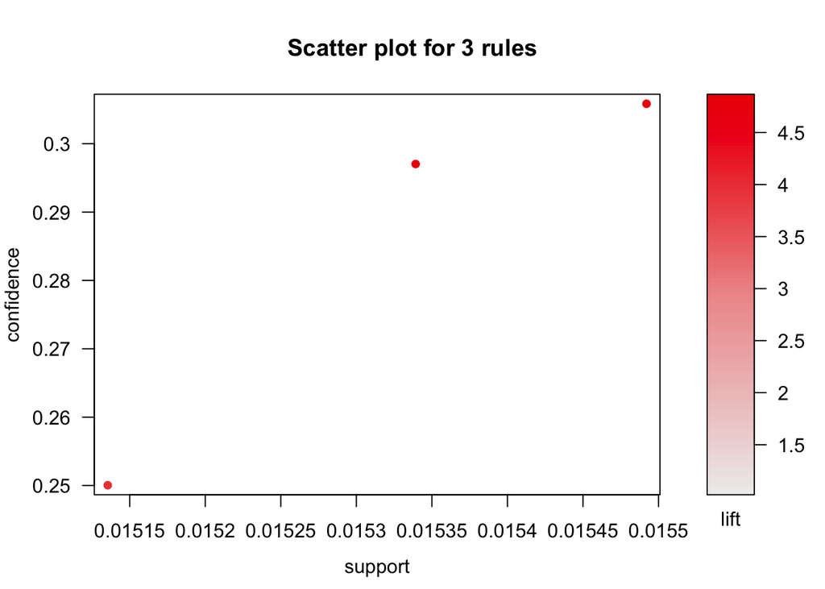

For income, the three maximal rules we found all had similar support around 1.5% but ranged in confidence from 25% to 30%.

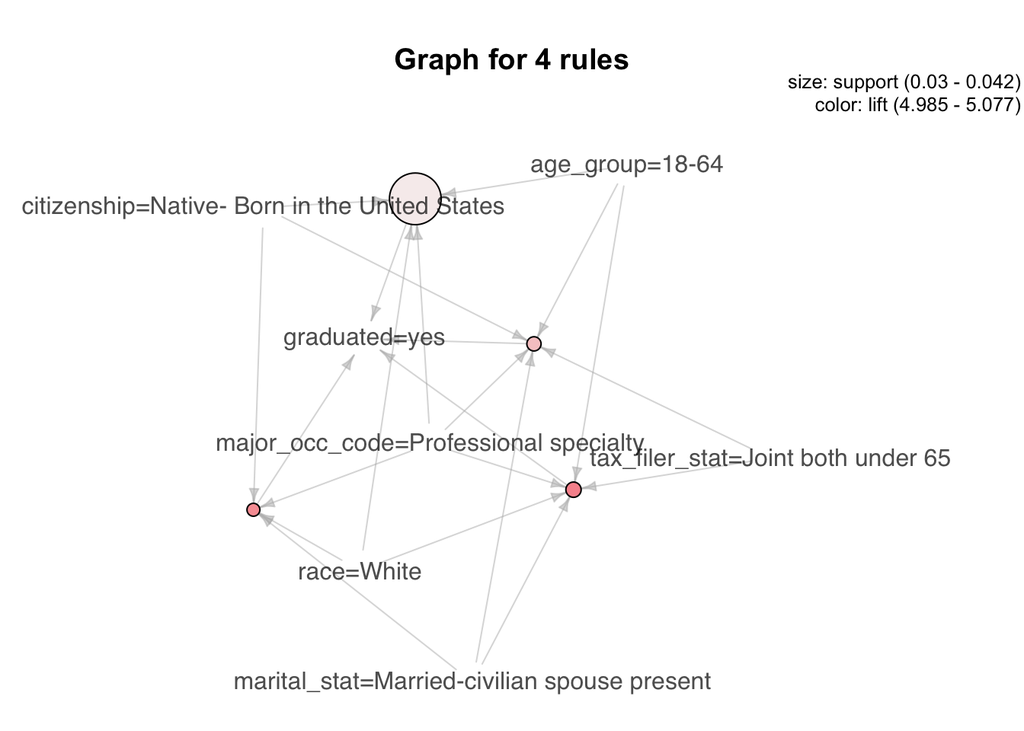

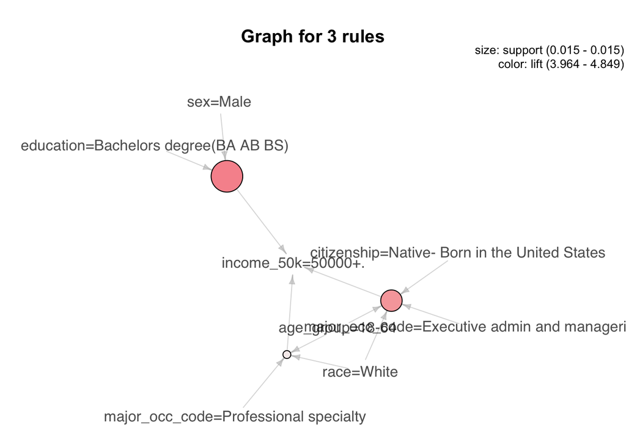

For income the rule sets associated with income over $50k are males with a bachelor degree or white 18-65 year olds that work in professional specialty or were native born citizens in executive admin or management.

## Modeling and Evaluation 4

Association Rules Ramifications

Since we are balancing both support and confidence, the best rules are subjective. That being said one of the few downsides that were touched upon in the above sections is that the support values where it gave us the best rules low. Anything above those numbers resulted in less rules or no rules. It would be beneficial if we were able to set higher support thresholds and get similar results.

Additionally, the confidence for the income set of rules is very low. This is telling us that the percentage of time the right hand rules events occurs is low given the left hand rules. One thing about having a higher support is that it applies more broadly which could make it more useful. However, the higher the confidence the more we can trust the rule. Optimizing more for support and confidence depends on the use case.

## Deployment

The below companies and parties might want to use our model to predict the following:

To predict income: IRS, Marketing agencies, Real Estate

To predict graduation: Job agency, Political parties, Graduate school recruiting

Graduate schools can use this model to target students who are more likely to do higher studies based on other attributes that are associated with higher education.

The model can be deployed in the cloud environment for high availability and scaling. The pipeline was designed so it can process the unseen data which than can be used in the model. This is so that anyone can easily utilize the model to process the unseen data. Other data that can be collected is real estate information (rent or own, type of home, price of home, etc…) and whether this individual will want to pursue a higher education. This type of model can be updated monthly based on additional data that is collected. However, updating more than a month is not necessary because these types of attributes are not prone to frequent change.

## Exceptional Work

Initially we only wanted to perform association rule mining on just income, but to compare we decided to also run a rule mining for the other class which is graduated. The values used for support and confidence are pasted again below to show for additional work.

```
## Apriori
##
## Parameter specification:
##  confidence minval smax arem  aval originalSupport maxtime support minlen
##        0.74    0.1    1 none FALSE            TRUE       5    0.03      1
##  maxlen target   ext
##      10  rules FALSE
##
## Algorithmic control:
##  filter tree heap memopt load sort verbose
##     0.1 TRUE TRUE  FALSE TRUE    2    TRUE
##
## Absolute minimum support count: 5888
##
## set item appearances ...[1 item(s)] done [0.00s].
## set transactions ...[146 item(s), 196294 transaction(s)] done [0.18s].
## sorting and recoding items ... [37 item(s)] done [0.02s].
## creating transaction tree ... done [0.16s].
## checking subsets of size 1 2 3 4 5 6 7 8 9 10 done [0.05s].
## writing ... [24 rule(s)] done [0.00s].
## creating S4 object  ... done [0.09s].
```

```
##      lhs                                                rhs                support confidence     lift count
## [1]  {major_occ_code=Professional specialty,
##       tax_filer_stat=Joint both under 65}            => {graduated=yes} 0.03505966  0.7621262 5.078961  6882
## [2]  {major_occ_code=Professional specialty,
##       marital_stat=Married-civilian spouse present}  => {graduated=yes} 0.03644533  0.7617121 5.076201  7154
## [3]  {age_group=18-64,
##       major_occ_code=Professional specialty}         => {graduated=yes} 0.05123947  0.7451474 4.965811 10058
## [4]  {major_occ_code=Professional specialty,
##       race=White}                                    => {graduated=yes} 0.04644564  0.7420037 4.944861  9117
## [5]  {major_occ_code=Professional specialty,
##       marital_stat=Married-civilian spouse present,
##       tax_filer_stat=Joint both under 65}            => {graduated=yes} 0.03485588  0.7629349 5.084350  6842
## [6]  {age_group=18-64,
##       major_occ_code=Professional specialty,
##       tax_filer_stat=Joint both under 65}            => {graduated=yes} 0.03505966  0.7622951 5.080087  6882
## [7]  {major_occ_code=Professional specialty,
##       race=White,
##       tax_filer_stat=Joint both under 65}            => {graduated=yes} 0.03131018  0.7607377 5.069708  6146
## [8]  {major_occ_code=Professional specialty,
##       tax_filer_stat=Joint both under 65,
##       citizenship=Native- Born in the United States} => {graduated=yes} 0.03101470  0.7542121 5.026220  6088
## [9]  {age_group=18-64,
##       major_occ_code=Professional specialty,
##       marital_stat=Married-civilian spouse present}  => {graduated=yes} 0.03559966  0.7618009 5.076794  6988
## [10] {major_occ_code=Professional specialty,
##       marital_stat=Married-civilian spouse present,
##       race=White}                                    => {graduated=yes} 0.03262453  0.7609316 5.071000  6404
```

```
##      support confidence     lift count
## 1 0.03505966  0.7621262 5.078961  6882
## 2 0.03644533  0.7617121 5.076201  7154
## 3 0.05123947  0.7451474 4.965811 10058
## 4 0.04644564  0.7420037 4.944861  9117
## 5 0.03485588  0.7629349 5.084350  6842
## 6 0.03505966  0.7622951 5.080087  6882
```

```
## [1] 24
```

```
##     lhs                                                rhs                support confidence     lift count
## [1] {age_group=18-64,
##      major_occ_code=Professional specialty,
##      marital_stat=Married-civilian spouse present,
##      race=White,
##      tax_filer_stat=Joint both under 65}            => {graduated=yes} 0.03115735  0.7618336 5.077011  6116
## [2] {major_occ_code=Professional specialty,
##      marital_stat=Married-civilian spouse present,
##      race=White,
##      citizenship=Native- Born in the United States} => {graduated=yes} 0.03043904  0.7606620 5.069203  5975
## [3] {age_group=18-64,
##      major_occ_code=Professional specialty,
##      marital_stat=Married-civilian spouse present,
##      tax_filer_stat=Joint both under 65,
##      citizenship=Native- Born in the United States} => {graduated=yes} 0.03084149  0.7552395 5.033067  6054
## [4] {age_group=18-64,
##      major_occ_code=Professional specialty,
##      race=White,
##      citizenship=Native- Born in the United States} => {graduated=yes} 0.04220710  0.7480137 4.984913  8285
```

```
## [1] 4
```

## Sources

UCI Citation for dataset: Dua, D. and Graff, C. (2019). UCI Machine Learning Repository [http://archive.ics.uci.edu/ml]. Irvine, CA: University of California, School of Information and Computer Science.

[Direct Link to Census-Income Dataset](https://www2.1010data.com/documentationcenter/prod/Tutorials/MachineLearningExamples/CensusIncomeDataSet.html)

[History of the Current Population Survey](https://www.census.gov/programs-surveys/cps/about/history-of-the-cps.html).

[Methodology of the Current Population Survey](https://www.census.gov/programs-surveys/cps/technical-documentation/methodology.html)

[Current Population Survey: Supplemental Survey Topics](https://www.census.gov/programs-surveys/cps/about/supplemental-surveys.html)

[Link to Association Rule article for insights](https://towardsdatascience.com/association-rules-2-aa9a77241654)